# Practical Machine Learning - Prediction Assignment

James Thomson

October 26, 2017

# Load required libraries

```r
library(lattice)
library(ggplot2)
library(caret)
library(randomForest)
library(rpart)
library(rpart.plot)
library(rattle)
```

# Background

Using devices such as Jawbone Up, Nike FuelBand, and Fitbit it is now possible to collect a large amount of data about personal activity relatively inexpensively. These type of devices are part of the quantified self movement - a group of enthusiasts who take measurements about themselves regularly to improve their health, to find patterns in their behavior, or because they are tech geeks. One thing that people regularly do is quantify how much of a particular activity they do, but they rarely quantify how well they do it. In this project, your goal will be to use data from accelerometers on the belt, forearm, arm, and dumbell of 6 participants. They were asked to perform barbell lifts correctly and incorrectly in 5 different ways. More information is available from the website here: http://web.archive.org/web/20161224072740/http:/groupware.les.inf.puc-rio.br/har (see the section on the Weight Lifting Exercise Dataset).

# Data

The training data for this project are available here:

https://d396qusza40orc.cloudfront.net/predmachlearn/pml-training.csv

The test data are available here:

https://d396qusza40orc.cloudfront.net/predmachlearn/pml-testing.csv

The data for this project come from this source: http://web.archive.org/web/20161224072740/http:/groupware.les.inf.puc-rio.br/har.

# Data Processing

#### Load data - remove any #DIV/0! values

```r
train.data <- read.csv("pml-training.csv", na.strings = c("NA", "#DIV/0!", ""))
test.data <- read.csv("pml-testing.csv", na.strings = c("NA", "#DIV/0!", ""))
```

#### Summary of the data

```r
dim(train.data)
```

```
## [1] 19622   160
```

```r
dim(test.data)
```

```
## [1]  20 160
```

There are 19,622 observations in the training dataset; 20 in the test dataset. Both datasets contain 160 variables.

# Clean data

#### Remove the first 7 columns as they will not be needed for the prediction

```r
train.data <- train.data[ , -(1:7)]
test.data <- test.data[ , -(1:7)]
dim(train.data)
```

```
## [1] 19622   153
```

```r
dim(test.data)
```

```
## [1]  20 153
```

We now have the same number of observations but only 153 variables.

#### NA values

There are many observations that contain NA:

```r
table(is.na(train.data))
```

```
##
##   FALSE    TRUE
## 1077064 1925102
```

```r
table(is.na(test.data))
```

```
##
## FALSE  TRUE
##  1060  2000
```

```r
train.data <- train.data[, colSums(is.na(train.data)) == 0]
test.data <- test.data[, colSums(is.na(test.data)) == 0]
```

# Partition the data

Partition the data into a training data set and a validation data set (I chose 75% training) for cross validation purposes.

Use the caret package: a set of functions that attempt to streamline the process for creating predictive models. The package continas tools for:

- data splitting
- pre-processing
- feature selection
- model tuning using resampling
- variable importance estimation

```r
train.part <- createDataPartition(train.data$classe, p = 0.75, list = FALSE)
train.set <- train.data[train.part, ]
test.set <- train.data[-train.part, ]
```

# Modeling

#### Decision Trees and Random Forests

Decision trees are a type of model used for both classification and regression. Trees answer sequential questions which send us down a certain route of the tree given the answer. The model behaves with “if this than that” conditions ultimately yielding a specific result.

A random forest is simply a collection of decision trees whose results are aggregated into one final result. Their ability to limit overfitting without substantially increasing error due to bias is why they are such powerful models.

Source: https://medium.com/towards-data-science/decision-trees-and-random-forests-df0c3123f991

#### Create a Random Forest model

```r
set.seed(12345)
rfmodel <- randomForest(classe ~ ., data = train.set, method = 'class')
rfpredict <- predict(rfmodel, test.set, type = "class")
rfmodel
```

```
##
## Call:
##  randomForest(formula = classe ~ ., data = train.set, method = "class")
##                Type of random forest: classification
##                      Number of trees: 500
## No. of variables tried at each split: 7
##
##         OOB estimate of  error rate: 0.44%
## Confusion matrix:
##      A    B    C    D    E  class.error
## A 4184    1    0    0    0 0.0002389486
## B   14 2831    3    0    0 0.0059691011
## C    0   16 2549    2    0 0.0070120764
## D    0    0   20 2391    1 0.0087064677
## E    0    0    1    7 2698 0.0029563932
```

```r
confusionMatrix(rfpredict, test.set$classe)
```

```
## Confusion Matrix and Statistics
##
##           Reference
## Prediction    A    B    C    D    E
##          A 1393    4    0    0    0
##          B    1  942    3    0    0
##          C    0    3  851    6    0
##          D    0    0    1  798    5
##          E    1    0    0    0  896
##
## Overall Statistics
##
##                Accuracy : 0.9951
##                  95% CI : (0.9927, 0.9969)
##     No Information Rate : 0.2845
##     P-Value [Acc > NIR] : < 2.2e-16
##
##                   Kappa : 0.9938
##  Mcnemar's Test P-Value : NA
##
## Statistics by Class:
##
##                      Class: A Class: B Class: C Class: D Class: E
## Sensitivity            0.9986   0.9926   0.9953   0.9925   0.9945
## Specificity            0.9989   0.9990   0.9978   0.9985   0.9998
## Pos Pred Value         0.9971   0.9958   0.9895   0.9925   0.9989
## Neg Pred Value         0.9994   0.9982   0.9990   0.9985   0.9988
## Prevalence             0.2845   0.1935   0.1743   0.1639   0.1837
## Detection Rate         0.2841   0.1921   0.1735   0.1627   0.1827
## Detection Prevalence   0.2849   0.1929   0.1754   0.1639   0.1829
## Balanced Accuracy      0.9987   0.9958   0.9965   0.9955   0.9971
```

Accuracy of over ~99% is very good. Out of sample error of ~0.5% is likewise excellent. In creating an almost perfect in-sample predictor we are capturing both signal AND the noise. This predictor may not woek as well on new data.

#### Create decision tree

```r
dtmodel <- rpart(classe ~ ., data = train.set, method = "class")
dtpredict <- predict(dtmodel, test.set, type = "class")
confusionMatrix(dtpredict, test.set$classe)
```

```
## Confusion Matrix and Statistics
##
##           Reference
## Prediction    A    B    C    D    E
##          A 1149  181   23   66   34
##          B   52  549  100   40  144
##          C   27   65  634  108  104
##          D  162  151   98  571  141
##          E    5    3    0   19  478
##
## Overall Statistics
##
##                Accuracy : 0.6894
##                  95% CI : (0.6763, 0.7024)
##     No Information Rate : 0.2845
##     P-Value [Acc > NIR] : < 2.2e-16
##
##                   Kappa : 0.6074
##  Mcnemar's Test P-Value : < 2.2e-16
##
## Statistics by Class:
##
##                      Class: A Class: B Class: C Class: D Class: E
## Sensitivity            0.8237   0.5785   0.7415   0.7102  0.53052
## Specificity            0.9134   0.9150   0.9249   0.8654  0.99326
## Pos Pred Value         0.7908   0.6203   0.6759   0.5085  0.94653
## Neg Pred Value         0.9287   0.9005   0.9443   0.9384  0.90384
## Prevalence             0.2845   0.1935   0.1743   0.1639  0.18373
## Detection Rate         0.2343   0.1119   0.1293   0.1164  0.09747
## Detection Prevalence   0.2963   0.1805   0.1913   0.2290  0.10298
## Balanced Accuracy      0.8685   0.7468   0.8332   0.7878  0.76189
```

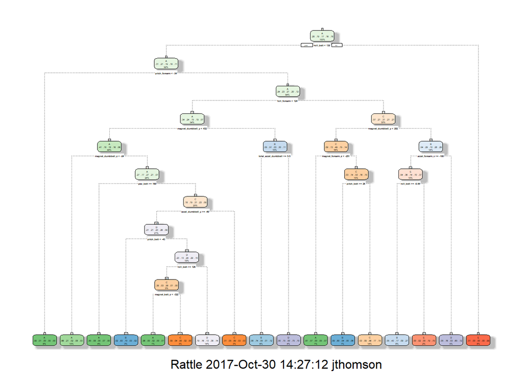

```r
fancyRpartPlot(dtmodel)
```

# Prediction

Use the model to predict the results for 20 tests

```r
prediction <- predict(rfmodel, test.data, type = "class")
prediction
```

```
##  1  2  3  4  5  6  7  8  9 10 11 12 13 14 15 16 17 18 19 20
##  B  A  B  A  A  E  D  B  A  A  B  C  B  A  E  E  A  B  B  B
## Levels: A B C D E
```